# MBA6693 - Business Analytics: Assignment-2

Shubh Sharma

Date of Submission: 18 July 2020

# 1. Introduction

In this document, we are going to find the best classification model (among Multinomial Logistic Regression, Linear Discriminant Analysis and k-Nearest Neighbors) that can fit the Iris data set. We will also look at the relationship between error rates and model complexity. We will also look at the relationship between several predictors and the response variable and find out which predictor(s) best describe the response variable.

# 2. Data Description

This data set is taken from University of California at Irvin’s Machine Learning Repository at https://archive.ics.uci.edu/ml/datasets/iris. The data set contains 3 classes of 50 instances each, where each class refers to a type of iris plant. One class is linearly separable from the other two while the latter two are not linearly separable from each other.

### Attribute Information

- Sepal Length (in cm)
- Sepal Width (in cm)
- Petal Length (in cm)
- Petal Width (in cm)
- Class: Iris Setosa, Iris Versicolour, Iris Virginica

### Libraries

- Important libraries needed for this classification problem are loaded below:

```r
library(ellipse)
library(caret)
```

```r
library(corrplot)
library(ggiraphExtra)
library(ggplot2)
library(broom)
library(readr)
library(MASS)
library(e1071)
library(nnet)
```

### Load Data

```r
iris_data_tribble <- read_csv("C:/Users/casa/Documents/MCS/Business Analytics/Assignments/Assignment2/iris_data.csv")
iris_data <- data.frame(iris)
```

### Data Structure

- Structure of the Iris data frame created above is shown below:

```r
str(iris_data)
```

```
## 'data.frame':    150 obs. of  5 variables:
##  $ Sepal.Length: num  5.1 4.9 4.7 4.6 5 5.4 4.6 5 4.4 4.9 ...
##  $ Sepal.Width : num  3.5 3 3.2 3.1 3.6 3.9 3.4 3.4 2.9 3.1 ...
##  $ Petal.Length: num  1.4 1.4 1.3 1.5 1.4 1.7 1.4 1.5 1.4 1.5 ...
##  $ Petal.Width : num  0.2 0.2 0.2 0.2 0.2 0.4 0.3 0.2 0.2 0.1 ...
##  $ Species     : Factor w/ 3 levels "setosa","versicolor",..: 1 1 1 1 1 1 1 1 1 1 ...
```

### Splitting the Data Set

- We will split the Iris data set into subsets in a ratio of 80:20 (training set:validation set).

```r
split_index <- createDataPartition(iris$Species, p=0.80, list=FALSE)
prediction_dataset <- iris[-split_index,]
# use the remaining 80% of data to training and testing the models
iris_data <- iris[split_index,]
View(prediction_dataset)
```

### Snapshot of Data

```r
head(iris_data)
```

```
##   Sepal.Length Sepal.Width Petal.Length Petal.Width Species
## 1          5.1         3.5          1.4         0.2  setosa
## 2          4.9         3.0          1.4         0.2  setosa
## 3          4.7         3.2          1.3         0.2  setosa
## 5          5.0         3.6          1.4         0.2  setosa
## 6          5.4         3.9          1.7         0.4  setosa
## 7          4.6         3.4          1.4         0.3  setosa
```

# 3. Exploratory Data Analysis

## (A) Univariate Analysis

- Dividing the input data set into two data sets that store inputs and output variables separately.

```r
inputs <- iris_data[,1:4]
output <- iris_data[,5]
```

### BoxPlots

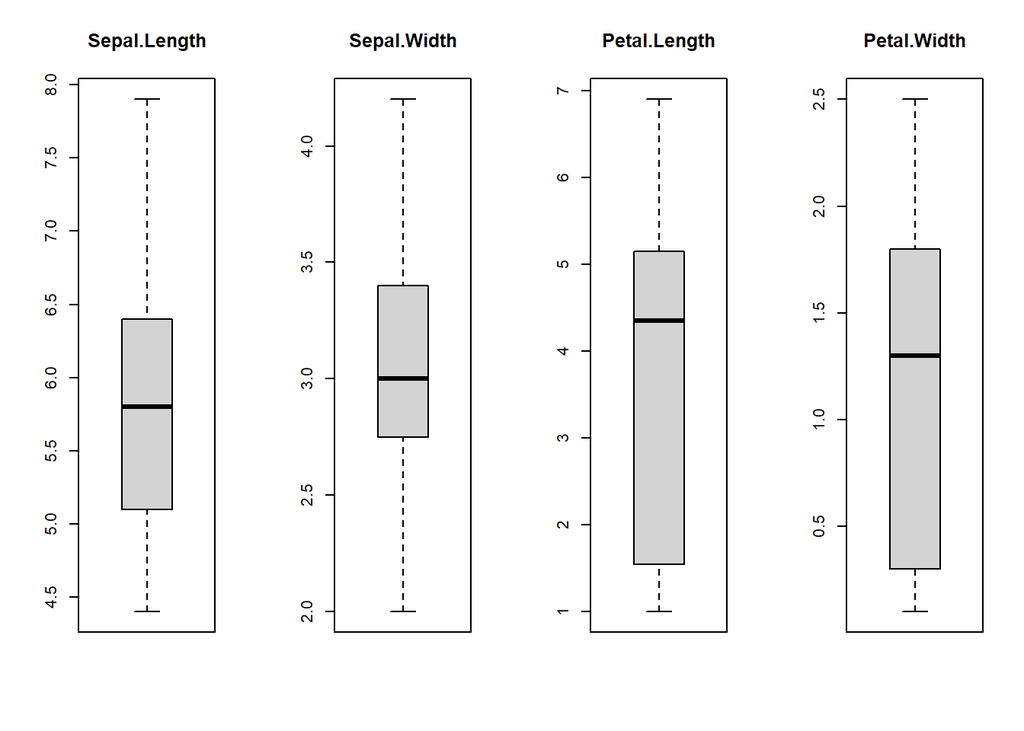

```r
# boxplot for each attribute on one image
par(mfrow=c(1,4))
  for(i in 1:4) {
  boxplot(inputs[,i], main=names(iris_data)[i])
}
```

### Histograms

- Histograms for each of the four predictors depicting data distribution

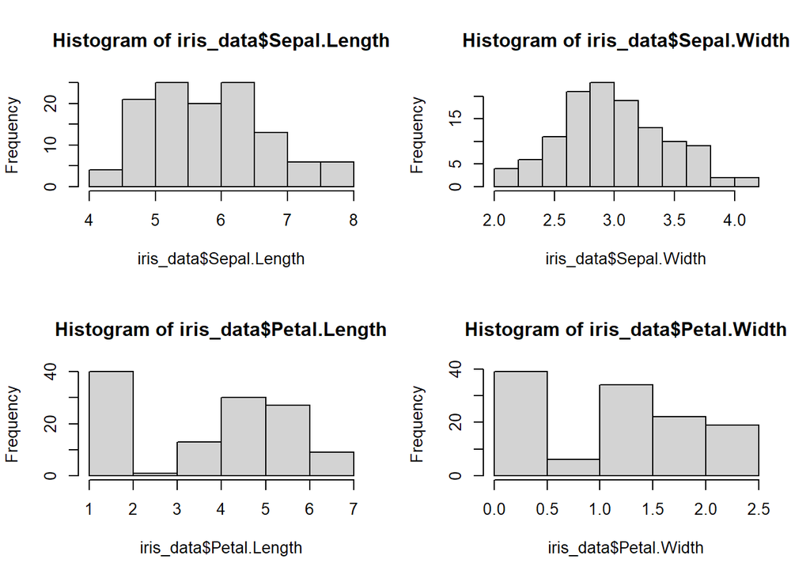

```r
par(mfrow=c(2,2))
  hist(iris_data$Sepal.Length)
  hist(iris_data$Sepal.Width)
  hist(iris_data$Petal.Length)
  hist(iris_data$Petal.Width)
```

## (B) Multivaruate Analysis

### BoxPlots against the Species Class

- Boxplots for each of the input attribute variables show that there are clearly different distributions of the attributes for each class value

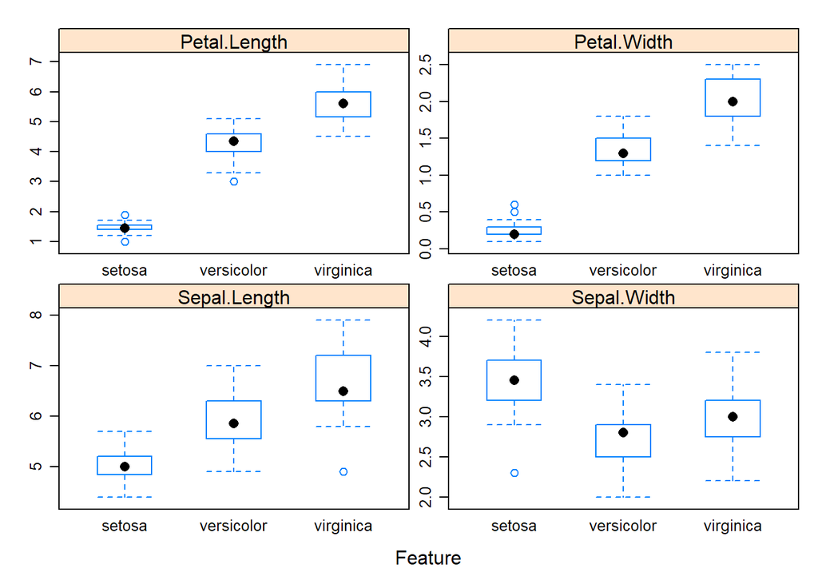

```r
featurePlot(x=iris_data[,1:4], y=iris_data[,5], plot="box", scales=list(x=list(relation="free"), y=list(relation="free")), auto.key=list(columns=3))
```

### Density Plots againt the Species Class

- We can see the difference in distribution of each attribute by class value. We can also see the Gaussian-like distribution (bell curve) of each attribute.

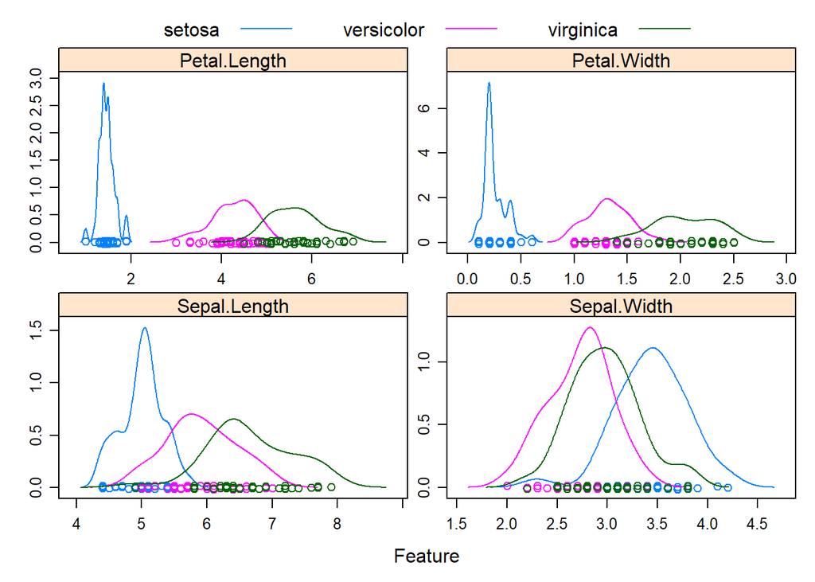

```r
featurePlot(x=iris_data[,1:4], y=iris_data[,5], plot="density", scales=list(x=list(relation="free"), y=list(relation="free")), auto.key=list(columns=3))
```

### Petal Length vs Petal Width plot

- The graph below shows the relationship between the petal length and width for the three classes.

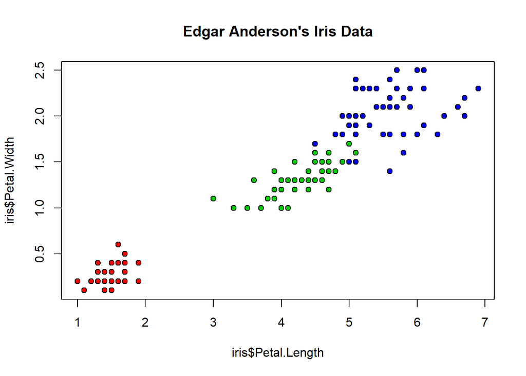

```r
plot(iris$Petal.Length, iris$Petal.Width, pch=21, bg=c("red","green3","blue")[unclass(iris$Species)], main="Edgar Anderson's Iris Data")
```

### Sepal Length vs Sepal Width plot

- The graph below shows the relationship between the sepal length and width for the three classes.

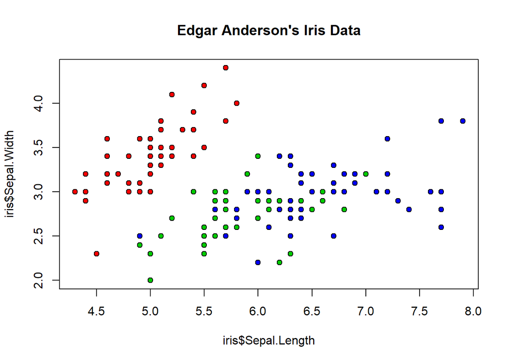

```r
plot(iris$Sepal.Length, iris$Sepal.Width, pch=21, bg=c("red","green3","blue")[unclass(iris$Species)], main="Edgar Anderson's Iris Data")
```

### Correlation

- The following plot shows the correlation between several predictors.
- We can see that Sepal.Width is not correlated very well to the other three predictors
- Sepal.Length, Petal.Length and Petal.width have high correlation amongst each other.

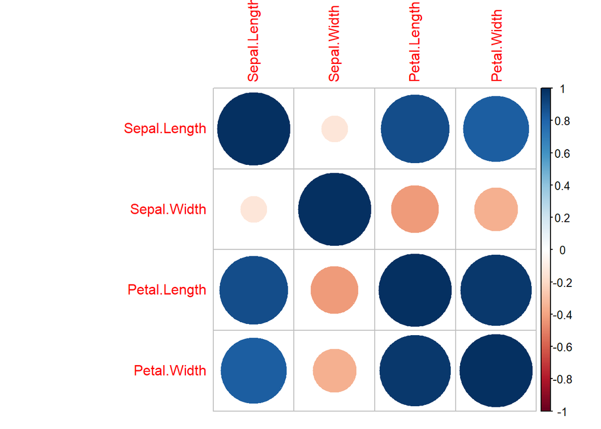

```r
correlations <- cor(iris_data[,1:4])
corrplot(correlations, method="circle")
```

### Overall Plot

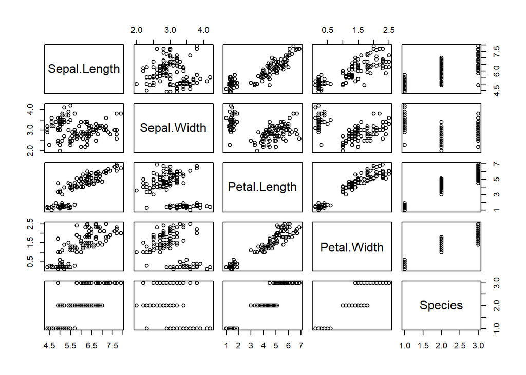

```r
plot(iris_data)
```

# 4. Models

- We are going to build 12 models using three algorithms: Multinomial Logistic Regression, Linear Discriminant Analysis and k-Nearest Neighbors.
- Steps To Be followed When applying an algorithm:
  - Split the data set into training and testing data set. The testing data set is generally smaller than training one as it will help in training the model better.
  - Select any algorithm based on the problem (classification here)
  - Then pass the training data set to the algorithm to train it
  - Then pass the testing data to the trained algorithm to predict the outcome
  - We then check the accuracy by passing the predicted outcome and the actual output to the model.

## (A) Logistic Regression

### Model Logit.1 (with one predictor)

```r
fit.glm=multinom(Species~Sepal.Length, data=iris_data)
print(fit.glm)
```

```
## Call:
## multinom(formula = Species ~ Sepal.Length, data = iris_data)
##
## Coefficients:
##            (Intercept) Sepal.Length
## versicolor   -26.35500     4.893025
## virginica    -40.37578     7.129275
##
## Residual Deviance: 140.4269
## AIC: 148.4269
```

### Model Logit.2 (with two predictors)

```r
fit.glm=multinom(Species~Sepal.Length+Sepal.Width, data=iris_data)
print(fit.glm)
```

```
## Call:
## multinom(formula = Species ~ Sepal.Length + Sepal.Width, data = iris_data)
##
## Coefficients:
##            (Intercept) Sepal.Length Sepal.Width
## versicolor   -64.94537     26.58106   -24.91311
## virginica    -79.61533     28.61507   -24.24538
##
## Residual Deviance: 83.01972
## AIC: 95.01972
```

### Model Logit.3 (with three predictors)

```r
fit.glm=multinom(Species~Sepal.Length+Sepal.Width+Petal.Width, data=iris_data)
print(fit.glm)
```

```
## Call:
## multinom(formula = Species ~ Sepal.Length + Sepal.Width + Petal.Width,
##     data = iris_data)
##
## Coefficients:
##            (Intercept) Sepal.Length Sepal.Width Petal.Width
## versicolor    3.036453     1.207452   -8.678977    19.84705
## virginica   -15.354691     2.558866  -13.150866    33.69409
##
## Residual Deviance: 23.89278
## AIC: 39.89278
```

### Model Logit.4 (with all predictors)

```r
fit.glm=multinom(Species~Sepal.Length+Sepal.Width+Petal.Width+Petal.Length, data=iris_data)
print(fit.glm)
```

```
## Call:
## multinom(formula = Species ~ Sepal.Length + Sepal.Width + Petal.Width +
##     Petal.Length, data = iris_data)
##
## Coefficients:
##            (Intercept) Sepal.Length Sepal.Width Petal.Width Petal.Length
## versicolor    17.11782    -6.542120   -6.150294  0.06251076     13.48148
## virginica    -21.09170    -8.825097  -13.206705 15.82412178     22.76436
##
## Residual Deviance: 10.12084
## AIC: 30.12084
```

## (B) Linear Discriminant Analysis (LDA)

### Model LDA.1 (with one predictor)

```r
control <- trainControl(method="cv", number=10)
metric <- "Accuracy"
set.seed(7)
fit.lda <- train(Species~Sepal.Length, data=iris_data, method="lda", metric=metric, trControl=control)
print(fit.lda)
```

```
## Linear Discriminant Analysis
##
## 120 samples
##   1 predictor
##   3 classes: 'setosa', 'versicolor', 'virginica'
##
## No pre-processing
## Resampling: Cross-Validated (10 fold)
## Summary of sample sizes: 108, 108, 108, 108, 108, 108, ...
## Resampling results:
##
##   Accuracy  Kappa
##   0.75      0.625
```

### Model LDA.2 (with two predictors)

```r
control <- trainControl(method="cv", number=10)
metric <- "Accuracy"
set.seed(7)
fit.lda <- train(Species~Sepal.Length+Sepal.Width, data=iris_data, method="lda", metric=metric, trControl=control)
print(fit.lda)
```

```
## Linear Discriminant Analysis
##
## 120 samples
##   2 predictor
##   3 classes: 'setosa', 'versicolor', 'virginica'
##
## No pre-processing
## Resampling: Cross-Validated (10 fold)
## Summary of sample sizes: 108, 108, 108, 108, 108, 108, ...
## Resampling results:
##
##   Accuracy   Kappa
##   0.7916667  0.6875
```

### Model LDA.3 (with three predictors)

```r
control <- trainControl(method="cv", number=10)
metric <- "Accuracy"
set.seed(7)
fit.lda <- train(Species~Sepal.Length+Sepal.Width+Petal.Width, data=iris_data, method="lda", metric=metric, trControl=control)
print(fit.lda)
```

```
## Linear Discriminant Analysis
##
## 120 samples
##   3 predictor
##   3 classes: 'setosa', 'versicolor', 'virginica'
##
## No pre-processing
## Resampling: Cross-Validated (10 fold)
## Summary of sample sizes: 108, 108, 108, 108, 108, 108, ...
## Resampling results:
##
##   Accuracy   Kappa
##   0.9333333  0.9
```

### Model LDA.4 (with all predictors)

```r
control <- trainControl(method="cv", number=10)
metric <- "Accuracy"
set.seed(7)
fit.lda <- train(Species~., data=iris_data, method="lda", metric=metric, trControl=control)
print(fit.lda)
```

```
## Linear Discriminant Analysis
##
## 120 samples
##   4 predictor
##   3 classes: 'setosa', 'versicolor', 'virginica'
##
## No pre-processing
## Resampling: Cross-Validated (10 fold)
## Summary of sample sizes: 108, 108, 108, 108, 108, 108, ...
## Resampling results:
##
##   Accuracy  Kappa
##   0.975     0.9625
```

### Observation

- The best model among all the LDA models is LDA.4 since it has the highest accuracy and lowest error. It is observed that as the complexity of the model increases, the error rate decreases.

## (C) kNN

### Model kNN.1 (with one predictor)

```r
set.seed(7)
fit.knn <- train(Species~Sepal.Length, data=iris_data, method="knn", metric=metric, trControl=control)
print(fit.knn)
```

```
## k-Nearest Neighbors
##
## 120 samples
##   1 predictor
##   3 classes: 'setosa', 'versicolor', 'virginica'
##
## No pre-processing
## Resampling: Cross-Validated (10 fold)
## Summary of sample sizes: 108, 108, 108, 108, 108, 108, ...
## Resampling results across tuning parameters:
##
##   k  Accuracy   Kappa
##   5  0.7416667  0.6125
##   7  0.7416667  0.6125
##   9  0.7666667  0.6500
##
## Accuracy was used to select the optimal model using the largest value.
## The final value used for the model was k = 9.
```

### Model kNN.2 (with two predictors)

```r
set.seed(7)
fit.knn <- train(Species~Sepal.Length+Sepal.Width, data=iris_data, method="knn", metric=metric, trControl=control)
print(fit.knn)
```

```
## k-Nearest Neighbors
##
## 120 samples
##   2 predictor
##   3 classes: 'setosa', 'versicolor', 'virginica'
##
## No pre-processing
## Resampling: Cross-Validated (10 fold)
## Summary of sample sizes: 108, 108, 108, 108, 108, 108, ...
## Resampling results across tuning parameters:
##
##   k  Accuracy   Kappa
##   5  0.8083333  0.7125
##   7  0.8166667  0.7250
##   9  0.8083333  0.7125
##
## Accuracy was used to select the optimal model using the largest value.
## The final value used for the model was k = 7.
```

### Model kNN.3 (with three predictors)

```r
set.seed(7)
fit.knn <- train(Species~Sepal.Length+Sepal.Width+Petal.Length, data=iris_data, method="knn", metric=metric, trControl=control)
print(fit.knn)
```

```
## k-Nearest Neighbors
##
## 120 samples
##   3 predictor
##   3 classes: 'setosa', 'versicolor', 'virginica'
##
## No pre-processing
## Resampling: Cross-Validated (10 fold)
## Summary of sample sizes: 108, 108, 108, 108, 108, 108, ...
## Resampling results across tuning parameters:
##
##   k  Accuracy   Kappa
##   5  0.9500000  0.925
##   7  0.9333333  0.900
##   9  0.9500000  0.925
##
## Accuracy was used to select the optimal model using the largest value.
## The final value used for the model was k = 9.
```

```r
set.seed(7)
fit.knn <- train(Species~Sepal.Length+Sepal.Width+Petal.Length+Petal.Width, data=iris_data, method="knn", metric=metric, trControl=control)
print(fit.knn)
```

```
## k-Nearest Neighbors
##
## 120 samples
##   4 predictor
##   3 classes: 'setosa', 'versicolor', 'virginica'
##
## No pre-processing
## Resampling: Cross-Validated (10 fold)
## Summary of sample sizes: 108, 108, 108, 108, 108, 108, ...
## Resampling results across tuning parameters:
##
##   k  Accuracy   Kappa
##   5  0.9583333  0.9375
##   7  0.9583333  0.9375
##   9  0.9583333  0.9375
##
## Accuracy was used to select the optimal model using the largest value.
## The final value used for the model was k = 9.
```

### Observation

- The best model among all the kNN models is kNN.4 since it has the highest accuracy and lowest error. It is observed that as the complexity of the model increases, the error rate decreases.

## Comparison between Models

```r
summary(fit.glm)
```

```
## Call:
## multinom(formula = Species ~ Sepal.Length + Sepal.Width + Petal.Width +
##     Petal.Length, data = iris_data)
##
## Coefficients:
##            (Intercept) Sepal.Length Sepal.Width Petal.Width Petal.Length
## versicolor    17.11782    -6.542120   -6.150294  0.06251076     13.48148
## virginica    -21.09170    -8.825097  -13.206705 15.82412178     22.76436
##
## Std. Errors:
##            (Intercept) Sepal.Length Sepal.Width Petal.Width Petal.Length
## versicolor    31.70120     82.35651    118.1875    37.34612     76.30254
## virginica     32.34734     82.38257    118.2893    37.78579     76.49036
##
## Residual Deviance: 10.12084
## AIC: 30.12084
```

```r
results <- resamples(list(lda=fit.lda, knn=fit.knn))
summary(results)
```

```
##
## Call:
## summary.resamples(object = results)
##
## Models: lda, knn
## Number of resamples: 10
##
## Accuracy
##          Min.   1st Qu. Median      Mean 3rd Qu. Max. NA's
## lda 0.9166667 0.9375000      1 0.9750000       1    1    0
## knn 0.8333333 0.9166667      1 0.9583333       1    1    0
##
## Kappa
##      Min. 1st Qu. Median   Mean 3rd Qu. Max. NA's
## lda 0.875 0.90625      1 0.9625       1    1    0
## knn 0.750 0.87500      1 0.9375       1    1    0
```

### Observation

# 5. Prediction

## Prediction by Model Logit.4

```r
predictions_glm <- predict(fit.glm, prediction_dataset)
print(predictions_glm)
```

```
##  [1] setosa     setosa     setosa     setosa     setosa     setosa
##  [7] setosa     setosa     setosa     setosa     versicolor versicolor
## [13] versicolor versicolor versicolor versicolor versicolor versicolor
## [19] versicolor versicolor virginica  virginica  virginica  virginica
## [25] virginica  virginica  virginica  versicolor virginica  virginica
## Levels: setosa versicolor virginica
```

```r
confusionMatrix(predictions_glm, prediction_dataset$Species)
```

```
## Confusion Matrix and Statistics
##
##             Reference
## Prediction   setosa versicolor virginica
##   setosa         10          0         0
##   versicolor      0         10         1
##   virginica       0          0         9
##
## Overall Statistics
##
##                Accuracy : 0.9667
##                  95% CI : (0.8278, 0.9992)
##     No Information Rate : 0.3333
##     P-Value [Acc > NIR] : 2.963e-13
##
##                   Kappa : 0.95
##
##  Mcnemar's Test P-Value : NA
##
## Statistics by Class:
##
##                      Class: setosa Class: versicolor Class: virginica
## Sensitivity                 1.0000            1.0000           0.9000
## Specificity                 1.0000            0.9500           1.0000
## Pos Pred Value              1.0000            0.9091           1.0000
## Neg Pred Value              1.0000            1.0000           0.9524
## Prevalence                  0.3333            0.3333           0.3333
## Detection Rate              0.3333            0.3333           0.3000
## Detection Prevalence        0.3333            0.3667           0.3000
## Balanced Accuracy           1.0000            0.9750           0.9500
```

## Prediction by Model LDA.4

```r
predictions_lda <- predict(fit.lda, prediction_dataset)
confusionMatrix(predictions_lda, prediction_dataset$Species)
```

```
## Confusion Matrix and Statistics
##
##             Reference
## Prediction   setosa versicolor virginica
##   setosa         10          0         0
##   versicolor      0         10         0
##   virginica       0          0        10
##
## Overall Statistics
##
##                Accuracy : 1
##                  95% CI : (0.8843, 1)
##     No Information Rate : 0.3333
##     P-Value [Acc > NIR] : 4.857e-15
##
##                   Kappa : 1
##
##  Mcnemar's Test P-Value : NA
##
## Statistics by Class:
##
##                      Class: setosa Class: versicolor Class: virginica
## Sensitivity                 1.0000            1.0000           1.0000
## Specificity                 1.0000            1.0000           1.0000
## Pos Pred Value              1.0000            1.0000           1.0000
## Neg Pred Value              1.0000            1.0000           1.0000
## Prevalence                  0.3333            0.3333           0.3333
## Detection Rate              0.3333            0.3333           0.3333
## Detection Prevalence        0.3333            0.3333           0.3333
## Balanced Accuracy           1.0000            1.0000           1.0000
```

## Prediction by Model kNN.4

```r
predictions_knn <- predict(fit.knn, prediction_dataset)
confusionMatrix(predictions_knn, prediction_dataset$Species)
```

```
## Confusion Matrix and Statistics
##
##             Reference
## Prediction   setosa versicolor virginica
##   setosa         10          0         0
##   versicolor      0         10         1
##   virginica       0          0         9
##
## Overall Statistics
##
##                Accuracy : 0.9667
##                  95% CI : (0.8278, 0.9992)
##     No Information Rate : 0.3333
##     P-Value [Acc > NIR] : 2.963e-13
##
##                   Kappa : 0.95
##
##  Mcnemar's Test P-Value : NA
##
## Statistics by Class:
##
##                      Class: setosa Class: versicolor Class: virginica
## Sensitivity                 1.0000            1.0000           0.9000
## Specificity                 1.0000            0.9500           1.0000
## Pos Pred Value              1.0000            0.9091           1.0000
## Neg Pred Value              1.0000            1.0000           0.9524
## Prevalence                  0.3333            0.3333           0.3333
## Detection Rate              0.3333            0.3333           0.3000
## Detection Prevalence        0.3333            0.3667           0.3000
## Balanced Accuracy           1.0000            0.9750           0.9500
```

### Observation

- As can be seen from the confusion matrices and the accuracy values, out of the three selected models (Logit.4, LDA.4 and kNN.4) LDA.4 predicts the best with the highest accuracy.

# 6. Conclusion

From our observations in Section 4 and 5 above, we conclude that:

- Sepal.Width is the least significant predictor among all predictors. However, it is still significant to the overall accuracy of all the models.
- as the complexity of the models increases, the error rate decreases
- the model LDA.4 that uses linear discriminant analysis for modeling the classification problem, preforms the best for the given data set.